# Simulations de l’impôt avec quotient conjugal

Benjamin Belrhomari

14 octobre 2019

# Illustration de l’effet du quotient conjugal

On définit un impôt progressif par tranches, similaire à l’IR français :

```r
impot <- function(revenu) {
  tranches = c(10000, 20000, 40000, 80000, Inf)
  taux = c(0, 0.05, 0.1, 0.25, 0.5)
  taxe = sum(diff(c(0, pmin(revenu, tranches))) * taux)

  return(taxe)
}
```

Pour une personne seule, le montant d’impôt en fonction du revenu peut être représenté de cette façon :

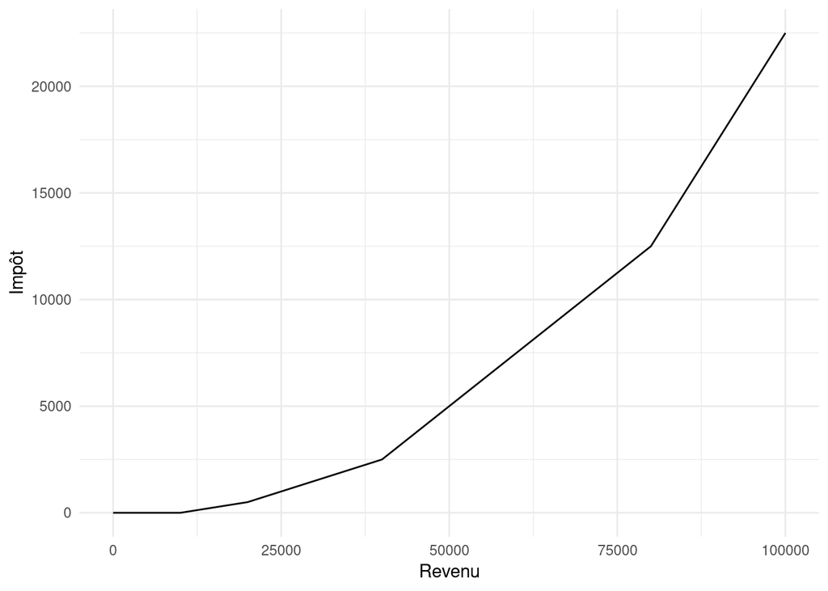

## Cas-type

Soient deux individus, $h$ et $f$, dont les revenus sont les suivants :

```r
zf = 5000
zh = 40000
```

On peut alors calculer leur impôt avec la taxation jointe :

```r
taxation_jointe = 2 * impot(0.5*zf + 0.5*zh)
taxation_jointe
```

```
## [1] 1500
```

Et avec la taxation séparée :

```r
taxation_separee = impot(zf) + impot(zh)
taxation_separee
```

```
## [1] 2500
```

L’avantage de la taxation jointe est donc :

```r
avantage = taxation_separee - taxation_jointe
avantage
```

```
## [1] 1000
```

## Graphes

On peut généraliser ce calcul, et le faire pour (par exemple) tous les revenus $z_f$ et $z_h$ compris entre 0 et 100000.

Limitons nous à 100 revenus possibles entre 1000€ et 100000€ soit 10000 couples possibles.

Pour chacun de ces couples, on peut calculer : * le montant de leur imposition jointe * le montant de leur imposition séparée * l’avantage de l’imposition jointe par rapport à l’imposition séparée * l’inégalité des revenus dans le couple, calculée ici comme la part des revenus du plus riche dans le total des revenus du ménage

```r
n = 100

df <- (
  expand.grid(
    zf = (1:n) * 100000 / n,
    zh = (1:n) * 100000 / n
    )
  %>% mutate(
    taxation_jointe = 2 * impot(0.5*zf + 0.5*zh),
    taxation_separee = impot(zf) + impot(zh),
    avantage = taxation_separee - taxation_jointe,
    part_du_plus_riche = pmax(zh, zf)/(zh+zf)
    )
  )
```

On peut alors représenter l’avantage relatif (avantage / taxation séparée) en fonction de l’inégalité dans le couple, qui est croissante :

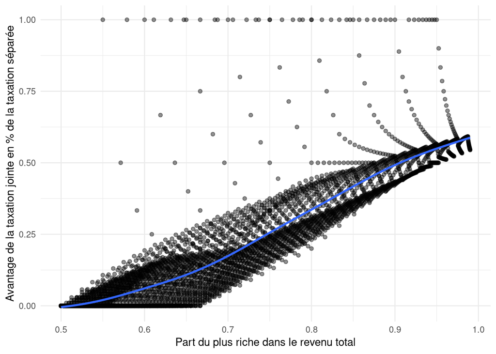

```r
(
  ggplot(df)
  + aes(
    x = part_du_plus_riche,
    y = avantage / taxation_separee
    )
  + geom_point(
      alpha = 0.25,
      position = position_jitter()
      )
  + geom_smooth(se = F)
  + theme_minimal()
  + labs(
    x = "Part du plus riche dans le revenu total",
    y = "Avantage de la taxation jointe en % de la taxation séparée"
  )
)
```

Et l’avantage en fonction des deux revenus. Les couples sur la diagonale sont parfaitement égalitaires ($z_{f} = z_{h}$) et plus on s’éloigne de la diagonale, plus le couple est inégalitaire.

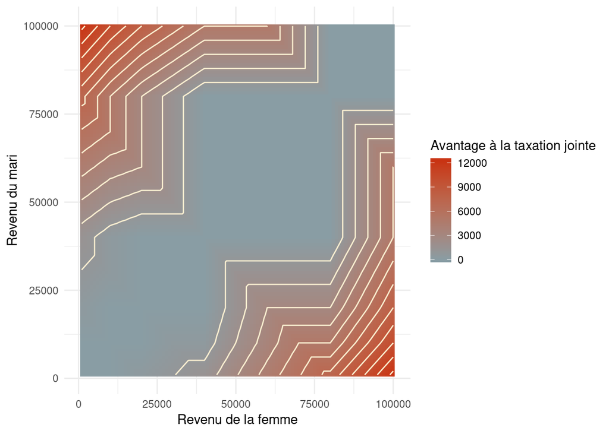

```r
(
  ggplot(df)
  + aes(
    x = zf,
    y = zh,
    fill = avantage,
    z = avantage
  )
  + geom_raster()
  + geom_contour(colour = "#FAEFD1")
  + scale_fill_continuous(low = "#899DA4", high = "#C93312")
  + theme_minimal()
  + labs(
    x = "Revenu de la femme",
    y = "Revenu du mari",
    fill = "Avantage à la taxation jointe"
  )
)
```